# Hypothesis testing

## Preliminaries

We will load the necessary libraries and datasets

```r
library(ggplot2)
library(dplyr)
library(ggpubr)
library(Hotelling)
library(tidyr)
library(vegan)
library(HDMD)
library(car) #for Manova
setwd('..')
path <- getwd()
setwd(paste(path, "/Results/FacePCA", sep = ""))
coeffs   <- read.csv("cleancoeffs.csv")
eigenvec <- read.csv("eigenvectors.csv", header=F)
eigenval <- read.csv("eigenvalues.csv", header=F)
means    <- read.csv("means.csv", header=F)
facets   <- read.csv("facets.csv", header=F)
set.seed(102)
coeffs200 <- coeffs[c(sample(rownames(coeffs[coeffs$Sex == "Female",]), 200),
                    sample(rownames(coeffs[coeffs$Sex == "Male",]), 200) ) , ]
```

## Facial sexual dimorphism analysis

### Differences in location

I will first test for differences in location between males in females in the face PCA. To do that I will use two different methods. In both methods I will use the full set of PCs, and a subset of the first 10 PCs. First, I will compare males and females location using Hotelling’s $T^{2}$ statistic, which is a multivariate t-test. The downside is that we cannot control for other covariates, such as Age and BMI. The results are virtually identical when using a normalized PC space (not shown here).

```r
fit <- hotelling.test(.~Sex, data = coeffs[,c(2, 7:ncol(coeffs))])
fit
```

```
## $stats
## $stats$statistic
## [1] 18876.67
##
## $stats$m
## [1] 0.01131024
##
## $stats$df
## [1]   87 5286
##
## $stats$nx
## [1] 3342
##
## $stats$ny
## [1] 2032
##
## $stats$p
## [1] 87
##
##
## $pval
## [1] 0
##
## attr(,"class")
## [1] "hotelling.test"
```

```r
fit10 <- hotelling.test(.~Sex, data = coeffs[,c(2, 7:16)])
fit10
```

```
## $stats
## $stats$statistic
## [1] 7485.059
##
## $stats$m
## [1] 0.09983246
##
## $stats$df
## [1]   10 5363
##
## $stats$nx
## [1] 3342
##
## $stats$ny
## [1] 2032
##
## $stats$p
## [1] 10
##
##
## $pval
## [1] 0
##
## attr(,"class")
## [1] "hotelling.test"
```

Second, I will use the more involved PERMANOVA (Anderson 2001) using the mahalanobis distance between males and females. The benefit of mahalanobis distance is that the within-group variance is taken into account, and not only the euclidean distance in space.

```r
fit <- adonis(coeffs[ , -(1:6)] ~ coeffs$Sex + coeffs$Age + coeffs$Height + coeffs$Weight,
              method="mahalanobis")
fit
```

```
##
## Call:
## adonis(formula = coeffs[, -(1:6)] ~ coeffs$Sex + coeffs$Age +      coeffs$Height + coeffs$Weight, method = "mahalanobis")
##
## Permutation: free
## Number of permutations: 999
##
## Terms added sequentially (first to last)
##
##                 Df SumsOfSqs MeanSqs F.Model      R2 Pr(>F)
## coeffs$Sex       1      4183  4182.7  49.249 0.00895  0.001 ***
## coeffs$Age       1      4261  4261.2  50.174 0.00912  0.001 ***
## coeffs$Height    1       582   581.9   6.852 0.00124  0.001 ***
## coeffs$Weight    1      2440  2440.3  28.733 0.00522  0.001 ***
## Residuals     5369    455985    84.9         0.97547
## Total         5373    467451                 1.00000
## ---
## Signif. codes:  0 '***' 0.001 '**' 0.01 '*' 0.05 '.' 0.1 ' ' 1
```

```r
fit10 <- adonis(coeffs[ , 7:16] ~ coeffs$Sex + coeffs$Age + coeffs$Height + coeffs$Weight,
                method="mahalanobis")
fit10
```

```
##
## Call:
## adonis(formula = coeffs[, 7:16] ~ coeffs$Sex + coeffs$Age + coeffs$Height +      coeffs$Weight, method = "mahalanobis")
##
## Permutation: free
## Number of permutations: 999
##
## Terms added sequentially (first to last)
##
##                 Df SumsOfSqs MeanSqs F.Model      R2 Pr(>F)
## coeffs$Sex       1      3128 3128.03  355.81 0.05822  0.001 ***
## coeffs$Age       1      1538 1537.84  174.93 0.02862  0.001 ***
## coeffs$Height    1       282  281.96   32.07 0.00525  0.001 ***
## coeffs$Weight    1      1582 1581.84  179.93 0.02944  0.001 ***
## Residuals     5369     47200    8.79         0.87847
## Total         5373     53730                 1.00000
## ---
## Signif. codes:  0 '***' 0.001 '**' 0.01 '*' 0.05 '.' 0.1 ' ' 1
```

We can also use the mahalanobis distance between group means as a measure of effect size. In this case there is nothing else to compare with, so we show the mahalanobis distance between males and females in the whole dataset.

```r
madist <- pairwise.mahalanobis(coeffs[, -(1:6)], coeffs$Sex)
madist$distance
```

```
##          [,1]     [,2]
## [1,] 0.000000 4.048683
## [2,] 4.048683 0.000000
```

### Differences in dispersion

I will use Anderson (2006) method for testing differences in dispersion between sexes

```r
dist <- vegdist(coeffs[, -(1:6)], method = "mahalanobis")
fit  <- betadisper(dist, coeffs$Sex)
anova(fit)
```

```
## Analysis of Variance Table
##
## Response: Distances
##             Df  Sum Sq Mean Sq F value    Pr(>F)
## Groups       1   191.8 191.846  84.406 < 2.2e-16 ***
## Residuals 5372 12210.0   2.273
## ---
## Signif. codes:  0 '***' 0.001 '**' 0.01 '*' 0.05 '.' 0.1 ' ' 1
```

```r
dist  <- vegdist(coeffs[, 7:16], method = "mahalanobis")
fit10 <- betadisper(dist, coeffs$Sex)
anova(fit10)
```

```
## Analysis of Variance Table
##
## Response: Distances
##             Df Sum Sq Mean Sq F value  Pr(>F)
## Groups       1    3.8  3.7856  6.2945 0.01214 *
## Residuals 5372 3230.8  0.6014
## ---
## Signif. codes:  0 '***' 0.001 '**' 0.01 '*' 0.05 '.' 0.1 ' ' 1
```

## Allometric and non-allometric components

In this section I will decompose the total facial sexual dimorphims (FSD) into its allometric and non-allometric components. To generate the total FSD vector, we will regress face shape on sex, using age and BMI as covariates.

```r
#Multivariate regression
formula <- as.matrix(coeffs[, -(1:6)]) ~ coeffs$Sex + coeffs$Age + coeffs$Weight +
                                         coeffs$Height
head(model.matrix(formula))
```

```
##   (Intercept) coeffs$SexMale coeffs$Age coeffs$Weight coeffs$Height
## 1           1              0         21          74.4       164.200
## 2           1              1         19          78.6       162.400
## 3           1              0         19          51.2       163.500
## 4           1              1         21          62.4       160.625
## 5           1              1         21          76.5       182.500
## 6           1              0         22          48.7       154.500
```

```r
model   <- lm(as.matrix(coeffs[, -(1:6)]) ~ coeffs$Sex + coeffs$Age + coeffs$Weight +
                                         coeffs$Height)
summary(manova(model), test="Pillai")
```

```
##                 Df  Pillai approx F num Df den Df    Pr(>F)
## coeffs$Sex       1 0.78220  218.086     87   5283 < 2.2e-16 ***
## coeffs$Age       1 0.79441  234.638     87   5283 < 2.2e-16 ***
## coeffs$Weight    1 0.43052   45.908     87   5283 < 2.2e-16 ***
## coeffs$Height    1 0.18521   13.804     87   5283 < 2.2e-16 ***
## Residuals     5369
## ---
## Signif. codes:  0 '***' 0.001 '**' 0.01 '*' 0.05 '.' 0.1 ' ' 1
```

```r
Manova(model)
```

```
##
## Type II MANOVA Tests: Pillai test statistic
##               Df test stat approx F num Df den Df    Pr(>F)
## coeffs$Sex     1   0.61488   96.951     87   5283 < 2.2e-16 ***
## coeffs$Age     1   0.78525  222.048     87   5283 < 2.2e-16 ***
## coeffs$Weight  1   0.45688   51.081     87   5283 < 2.2e-16 ***
## coeffs$Height  1   0.18521   13.804     87   5283 < 2.2e-16 ***
## ---
## Signif. codes:  0 '***' 0.001 '**' 0.01 '*' 0.05 '.' 0.1 ' ' 1
```

```r
model10 <- lm(as.matrix(coeffs[, 7:16]) ~ coeffs$Sex + coeffs$Age + coeffs$Weight +
                                             coeffs$Height)
summary(manova(model10), test="Pillai")
```

```
##                 Df  Pillai approx F num Df den Df    Pr(>F)
## coeffs$Sex       1 0.58976   770.55     10   5360 < 2.2e-16 ***
## coeffs$Age       1 0.28972   218.64     10   5360 < 2.2e-16 ***
## coeffs$Weight    1 0.26449   192.74     10   5360 < 2.2e-16 ***
## coeffs$Height    1 0.12135    74.03     10   5360 < 2.2e-16 ***
## Residuals     5369
## ---
## Signif. codes:  0 '***' 0.001 '**' 0.01 '*' 0.05 '.' 0.1 ' ' 1
```

```r
Manova(model10)
```

```
##
## Type II MANOVA Tests: Pillai test statistic
##               Df test stat approx F num Df den Df    Pr(>F)
## coeffs$Sex     1   0.35607  296.394     10   5360 < 2.2e-16 ***
## coeffs$Age     1   0.28605  214.749     10   5360 < 2.2e-16 ***
## coeffs$Weight  1   0.29643  225.834     10   5360 < 2.2e-16 ***
## coeffs$Height  1   0.12135   74.028     10   5360 < 2.2e-16 ***
## ---
## Signif. codes:  0 '***' 0.001 '**' 0.01 '*' 0.05 '.' 0.1 ' ' 1
```

```r
#Calculating the average position
Males   <- colMeans(coeffs[coeffs$Sex == 'Male', -(1:6)])
Females <- colMeans(coeffs[coeffs$Sex == 'Female', -(1:6)])
consensus <- as.data.frame(t(data.frame(Males, Females)))
remove(Males, Females)
```

We can see the position of the average male and female faces in the first PCs. The male and female consensus faces are highlighted to show their position in relation to the whole data set.

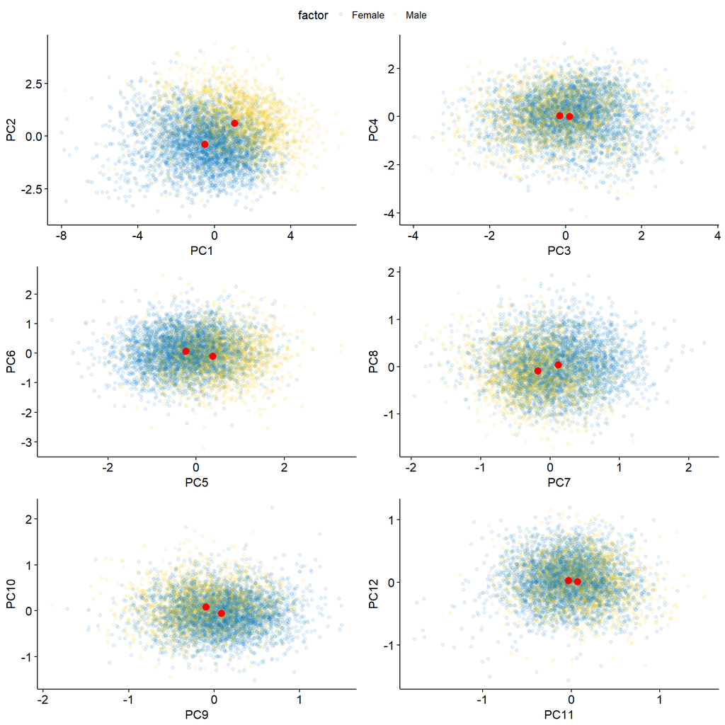

```r
plotmeans <- function(matrix, means, factor, x1, y1)
{
  p1 <- ggplot(matrix, aes_string(x = x1, y = y1)) +
            geom_point(aes(colour = factor), alpha=0.1) +
            geom_point(data = means, aes_string(x = x1, y = y1), color="red", size=3) +
            theme_pubr()
  p1 <- ggpar(p1, palette = "jco")
  return(p1)
}
p1 <- plotmeans(coeffs[, -(1:6)], consensus, coeffs$Sex, "PC1", "PC2")
p2 <- plotmeans(coeffs[, -(1:6)], consensus, coeffs$Sex, "PC3", "PC4")
p3 <- plotmeans(coeffs[, -(1:6)], consensus, coeffs$Sex, "PC5", "PC6")
p4 <- plotmeans(coeffs[, -(1:6)], consensus, coeffs$Sex, "PC7", "PC8")
p5 <- plotmeans(coeffs[, -(1:6)], consensus, coeffs$Sex, "PC9", "PC10")
p6 <- plotmeans(coeffs[, -(1:6)], consensus, coeffs$Sex, "PC11", "PC12")

ggarrange(p1, p2, p3, p4, p5, p6,
          ncol=2, nrow=3,
          common.legend = T, legend = "top")
```

To obtain the allometric component, we use the previous multivariate linear regression. To decompose the total FSD into its allometric and non-allometric components, we use the estimated effect of height on the face, scaled by the mean difference between females and males.

```r
consensus[3,] <- model$coefficients[2,]
consensus[4,] <- coef(model)[5,] * (mean(coeffs[coeffs$Sex == 'Male',4]) -
                                    mean(coeffs[coeffs$Sex == 'Female',4]))
consensus[5,] <- as.numeric(consensus[3,]) - consensus[4,]
row.names(consensus) <- c("Males", "Females", "TotalSD", "Allometric", "Non-allometric")
```

We can graphically see the magnitude and direction of the vectors. Note that in the plots, the vectors are scaled by 3.

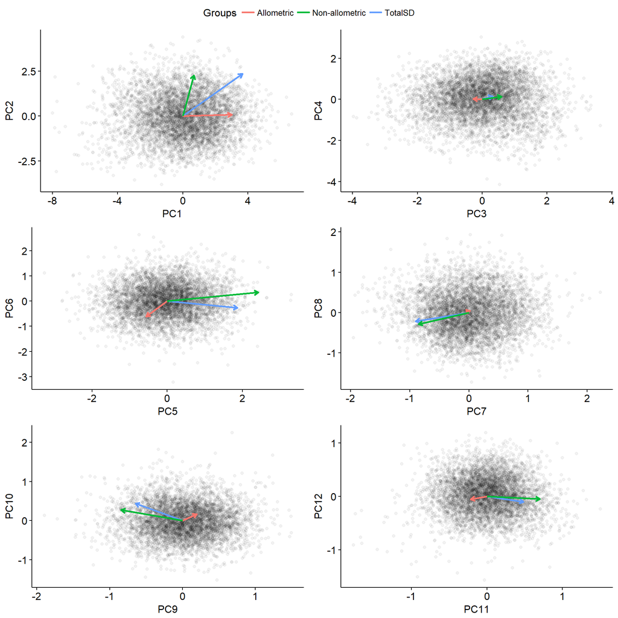

```r
source("PlotPCs.R")
p1 <- plotvect(coeffs[, -(1:6)], rownames(consensus)[3:5], consensus[3:5,], "PC1", "PC2")
p2 <- plotvect(coeffs[, -(1:6)], rownames(consensus)[3:5], consensus[3:5,], "PC3", "PC4")
p3 <- plotvect(coeffs[, -(1:6)], rownames(consensus)[3:5], consensus[3:5,], "PC5", "PC6")
p4 <- plotvect(coeffs[, -(1:6)], rownames(consensus)[3:5], consensus[3:5,], "PC7", "PC8")
p5 <- plotvect(coeffs[, -(1:6)], rownames(consensus)[3:5], consensus[3:5,], "PC9", "PC10")
p6 <- plotvect(coeffs[, -(1:6)], rownames(consensus)[3:5], consensus[3:5,], "PC11", "PC12")

ggarrange(p1, p2, p3, p4, p5, p6,
          ncol=2, nrow=3,
          common.legend = T, legend = "top")
```

We export the fitted model and the vectors to visualize them as face shapes, here.

```r
setwd('..')
path <- getwd()
setwd(paste(path, "/Results/FSD", sep = ""))
write.csv(consensus, "vectors.csv", quote = F)
save(fit, file = "fitmodel.RData")
```